# Chapter 06, Problem Set Key

### 6.1

$$\begin{aligned}
\frac{dN_1}{dt} &= b_1N_1N_2 - m_1N_1 \\
\frac{dN_2}{dt} &= b_2N_2 - m_2N_1N_2
\end{aligned}$$

### 6.2

From the equations you derived in exercise 6.1, calculate the equilibrium conditions for both equations, and plot those conditions on a graph of $N_1$ versus $N_2$, indicating the values of the intercepts. Note that each of the resulting lines is called an isocline.

For eqn. 1:
$$\begin{aligned}
&0 = b_1N_1N_2 - m_1N_1 \\
&0 = N_1(b_1N_2 - m_1) \\
&\text{The first equilibrium is } N^*_1 = 0 \\
&\text{Setting }b_1N_2 - m_1\text{ to 0 will also be an equilibirum} \\
&0 = b_1N_2 - m_1 \\
&b_1N_2 = m_1 \\
&\text{The second equilibrium is }N^*_2 = \frac{m_1}{b_1}
\end{aligned}$$

For eqn. 2:
$$\begin{aligned}
&0 = b_2 N_2 - m_2N_1N_2 \\
&0 = N_2(b_2 - m_2N_1) \\
&\text{The first equilibrium is } N^*_2 = 0 \\
&\text{Setting }b_2 - m_2N_1 \text{ to 0 will also be an equilibirum} \\
&0 = b_2 - m_2N_1 \\
&m_2N_1 = b_2 \\
&\text{The second equilibrium is }N^*_1 = \frac{b_2}{m_2}
\end{aligned}$$

Label the isoclines for the first equation in red and the second equation in blue.

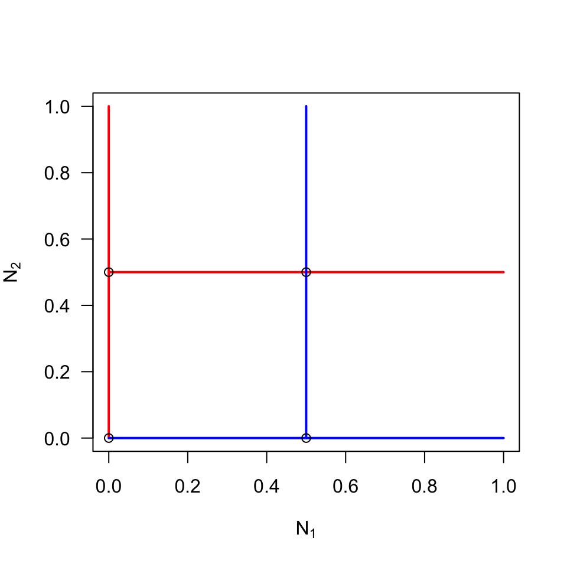

```r
b1 <- 0.2
m1 <- 0.1
b2 <- 0.2
m2 <- 0.4

plot(x = NA, type = "n", xlim = c(0, 1), ylim = c(0, 1), las = 1, xlab = bquote(N[1]), ylab = bquote(N[2]))
  segments(x0 = 0, y0 = 0, x1 = 0, y1 = 1, lwd = 2, col = "red")
  segments(x0 = 0, y0 = m1/b1, x1 = 1, y1 = m1/b1, lwd = 2, col = "red")
  segments(x0 = 0, y0 = 0, x1 = 1, y1 = 0, lwd = 2, col = "blue")
  segments(x0 = b2/m2, y0 = 0, x1 = b2/m2, y1 = 1, lwd = 2, col = "blue")

points(x = 0, y = 0)
points(x = m1/b1, y = 0)
points(x = 0, y = b2/m2)
points(x = m1/b1, y = b2/m2)
```

### 6.3

Using the basic form of the Lotka–Volterra equations (3a and 3b), replace the exponential part of the “victim” equation with the logistic equation and solve for the equilibrium state, expressing the critical value of $P$ as a function of $V$. Plot the isocline.

$$\begin{aligned}
\frac{dV}{dt} &= rV - aPV\\
\frac{dP}{dt} &= bVP - mP
\end{aligned}$$

For eqn. 1:
$$\begin{aligned}
&0 = rV\left(\frac{K - V}{K}\right) - aPV \\
&0 = V(r\left(\frac{K - V}{K}\right) - aP) \\
&\text{The first equilibrium is } V^* = 0 \\
&\text{Setting } r\left(\frac{K - V}{K}\right) - aP \text{ to 0 will also be an equilibirum} \\
&0 = r\left(\frac{K - V}{K}\right) - aP \\
& aP = r\left(\frac{K - V}{K}\right) \\
&\text{The second equilibrium is }P^* = \frac{r}{a}\left(\frac{K - V}{K}\right)
\end{aligned}$$

Label the isoclines for the first equation.

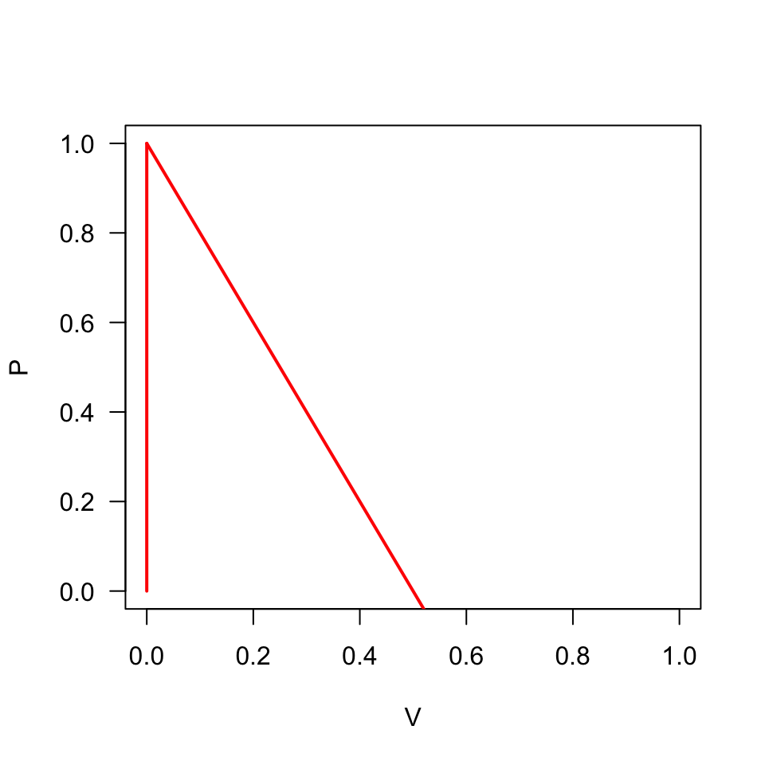

```r
r <- 0.2
K <- 0.5
a <- 0.2
V <- seq(from = 0, to = 1, by = 0.01)

isocline_2 <- r/a*((K - V) / K)

plot(x = NA, type = "n", xlim = c(0, 1), ylim = c(0, 1), las = 1, xlab = "V", ylab = "P")
  segments(x0 = 0, x1 = 0, y0 = 0, y1 = 1, lwd = 2, col = "red")
  lines(x = V, y = isocline_2, lwd = 2, col = "red")
```

### 6.4

Using the basic form of the Lotka–Volterra equations (3a and 3b), replace the exponential part of the predator equation with the logistic equation and solve for the equilibrium state, expressing the critical value of P as a function of $V$. Plot the isoclines.

$$\begin{aligned}
\frac{dV}{dt} &= rV - aPV\\
\frac{dP}{dt} &= rPV\left(\frac{K - P}{K}\right) - mP
\end{aligned}$$

For eqn. 2:
$$\begin{aligned}
&0 = rPV\left(\frac{K - P}{K}\right) - mP \\
&0 = P(rV\left(\frac{K - P}{K}\right) - m) \\
&\text{The first equilibrium is } P^* = 0 \\
&\text{Setting } rV\left(\frac{K - P}{K}\right) - m \text{ to 0 will also be an equilibirum} \\
&0 = rV\left(\frac{K - P}{K}\right) - m \\
&0 = rV - \left(\frac{rVP}{K}\right) - m \\
&\frac{rVP}{K} = rV - m \\
&P = \frac{K\left(rV - m\right)}{rV} \\
&\text{The second equilibrium is }P^* = K - \frac{Km}{rV}
\end{aligned}$$

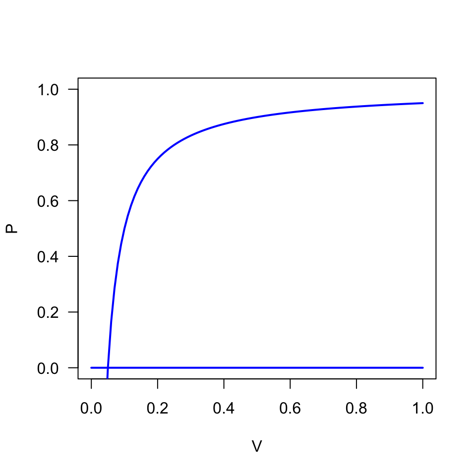

```r
r <- 0.2
K <- 1
m <- 0.01
V <- seq(from = 0, to = 1, by = 0.01)

isocline_2 <- K - K*m/(r*V)

plot(x = NA, type = "n", xlim = c(0, 1), ylim = c(0, 1), las = 1, xlab = "V", ylab = "P")
  segments(x0 = 0, x1 = 1, y0 = 0, y1 = 0, lwd = 2, col = "blue")
  lines(x = V, y = isocline_2, lwd = 2, col = "blue")
```

### 6.5

On the graphs you made in exercise 6.2, shade the four areas that represent the four different states possible: (1) predator increasing, prey increasing; (2) predator increasing, prey decreasing; (3) predator decreasing, prey increasing; and (4) predator decreasing, prey decreasing. Now keep the equilibrium point (the point where the two isoclines cross) the same but change the prey isocline so that it is declining. Remember that the isoclines still separate those four critical dynamic areas. Compare the general areas of the vector field (the collection of vectors that indicate the general dynamics of the system), and guess what the overall change in behavior of the system will be.

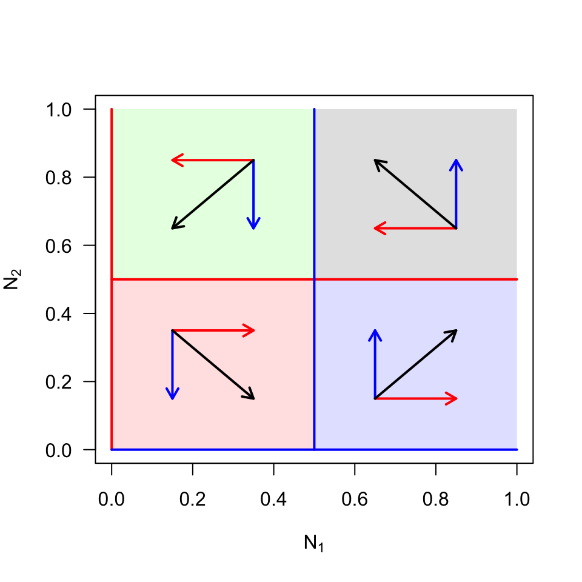

```r
b1 <- 0.2
m1 <- 0.1
b2 <- 0.2
m2 <- 0.4

plot(x = NA, type = "n", xlim = c(0, 1), ylim = c(0, 1), las = 1, xlab = bquote(N[1]), ylab = bquote(N[2]))
  polygon(x = c(0, 0, b2/m2, b2/m2), y = c(0, m1/b1, m1/b1, 0), col = "#FF000022", border = F)
  polygon(x = c(0, 0, b2/m2, b2/m2), y = c(m1/b1, 1, 1, m1/b1), col = "#00FF0022", border = F)
  polygon(x = c(b2/m2, b2/m2, 1, 1), y = c(0, m1/b1, m1/b1, 0), col = "#0000FF22", border = F)
  polygon(x = c(b2/m2, b2/m2, 1, 1), y = c(m1/b1, 1, 1, m1/b1), col = "#00000022", border = F)

  segments(x0 = 0, y0 = 0, x1 = 0, y1 = 1, lwd = 2, col = "red")
  segments(x0 = 0, y0 = m1/b1, x1 = 1, y1 = m1/b1, lwd = 2, col = "red")
  segments(x0 = 0, y0 = 0, x1 = 1, y1 = 0, lwd = 2, col = "blue")
  segments(x0 = b2/m2, y0 = 0, x1 = b2/m2, y1 = 1, lwd = 2, col = "blue")

arrows(x0 = 0.15, x1 = 0.35, y0 = 0.35, y1 = 0.35, length = 0.1,lwd = 2, col = "red")
arrows(x0 = 0.15, x1 = 0.15, y0 = 0.35, y1 = 0.15, length = 0.1,lwd = 2, col = "blue")
arrows(x0 = 0.15, x1 = 0.35, y0 = 0.35, y1 = 0.15, length = 0.1,lwd = 2, col = "black")

arrows(x0 = 0.35, x1 = 0.15, y0 = 0.85, y1 = 0.85, length = 0.1,lwd = 2, col = "red")
arrows(x0 = 0.35, x1 = 0.35, y0 = 0.85, y1 = 0.65, length = 0.1,lwd = 2, col = "blue")
arrows(x0 = 0.35, x1 = 0.15, y0 = 0.85, y1 = 0.65, length = 0.1,lwd = 2, col = "black")

arrows(x0 = 0.85, x1 = 0.65, y0 = 0.65, y1 = 0.65, length = 0.1,lwd = 2, col = "red")
arrows(x0 = 0.85, x1 = 0.85, y0 = 0.65, y1 = 0.85, length = 0.1,lwd = 2, col = "blue")
arrows(x0 = 0.85, x1 = 0.65, y0 = 0.65, y1 = 0.85, length = 0.1,lwd = 2, col = "black")

arrows(x0 = 0.65, x1 = 0.85, y0 = 0.15, y1 = 0.15, length = 0.1,lwd = 2, col = "red")
arrows(x0 = 0.65, x1 = 0.65, y0 = 0.15, y1 = 0.35, length = 0.1,lwd = 2, col = "blue")
arrows(x0 = 0.65, x1 = 0.85, y0 = 0.15, y1 = 0.35, length = 0.1,lwd = 2, col = "black")
```

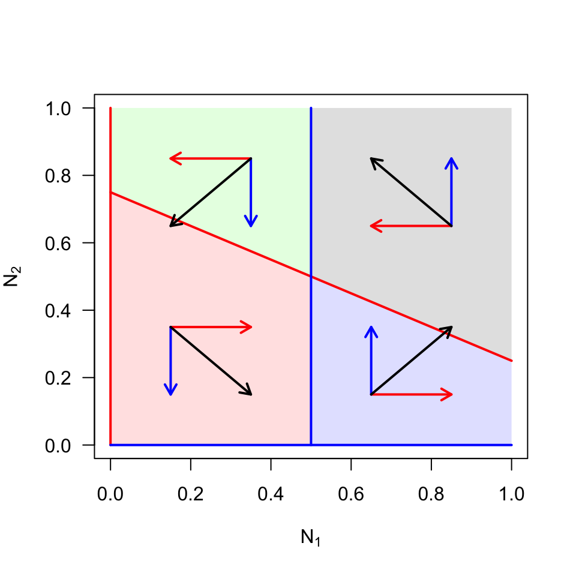

```r
b1 <- 1
m1 <- 0.75
b2 <- 0.2
m2 <- 0.4

plot(x = NA, type = "n", xlim = c(0, 1), ylim = c(0, 1), las = 1, xlab = bquote(N[1]), ylab = bquote(N[2]))
  polygon(x = c(0, 0, b2/m2, b2/m2), y = c(0, m1/b1, 0.5, 0), col = "#FF000022", border = F)
  polygon(x = c(0, 0, b2/m2, b2/m2), y = c(m1/b1, 1, 1, 0.5), col = "#00FF0022", border = F)
  polygon(x = c(b2/m2, b2/m2, 1, 1), y = c(0, 0.5, 0.25, 0), col = "#0000FF22", border = F)
  polygon(x = c(b2/m2, b2/m2, 1, 1), y = c(0.5, 1, 1, 0.25), col = "#00000022", border = F)

  # I just picked points where I know the lines would cross and filled in
  # the values below in segments.
  segments(x0 = 0, y0 = 0, x1 = 0, y1 = 1, lwd = 2, col = "red")
  segments(x0 = 0, y0 = m1/b1, x1 = 1, y1 = 0.25, lwd = 2, col = "red")
  segments(x0 = 0, y0 = 0, x1 = 1, y1 = 0, lwd = 2, col = "blue")
  segments(x0 = b2/m2, y0 = 0, x1 = b2/m2, y1 = 1, lwd = 2, col = "blue")

arrows(x0 = 0.15, x1 = 0.35, y0 = 0.35, y1 = 0.35, length = 0.1,lwd = 2, col = "red")
arrows(x0 = 0.15, x1 = 0.15, y0 = 0.35, y1 = 0.15, length = 0.1,lwd = 2, col = "blue")
arrows(x0 = 0.15, x1 = 0.35, y0 = 0.35, y1 = 0.15, length = 0.1,lwd = 2, col = "black")

arrows(x0 = 0.35, x1 = 0.15, y0 = 0.85, y1 = 0.85, length = 0.1,lwd = 2, col = "red")
arrows(x0 = 0.35, x1 = 0.35, y0 = 0.85, y1 = 0.65, length = 0.1,lwd = 2, col = "blue")
arrows(x0 = 0.35, x1 = 0.15, y0 = 0.85, y1 = 0.65, length = 0.1,lwd = 2, col = "black")

arrows(x0 = 0.85, x1 = 0.65, y0 = 0.65, y1 = 0.65, length = 0.1,lwd = 2, col = "red")
arrows(x0 = 0.85, x1 = 0.85, y0 = 0.65, y1 = 0.85, length = 0.1,lwd = 2, col = "blue")
arrows(x0 = 0.85, x1 = 0.65, y0 = 0.65, y1 = 0.85, length = 0.1,lwd = 2, col = "black")

arrows(x0 = 0.65, x1 = 0.85, y0 = 0.15, y1 = 0.15, length = 0.1,lwd = 2, col = "red")
arrows(x0 = 0.65, x1 = 0.65, y0 = 0.15, y1 = 0.35, length = 0.1,lwd = 2, col = "blue")
arrows(x0 = 0.65, x1 = 0.85, y0 = 0.15, y1 = 0.35, length = 0.1,lwd = 2, col = "black")
```